# Report Weekly Assignment 4

Mei Gascón

16 noviembre, 2023

### Abstract

*We use SNPdataset.txt datset in order to practice and learn new plots for genetic data visualization. We create different histograms and boxplot to analyze the distribution of the variable GENE_EXPRESSION. In addition , we use facet wrap and facet grid to show the frequency of each genotype.*

### Introduction

This is the dataset SNPdataset.txt:

| CASECONTROL | SNP1 | SNP2 | SNP3 | SNP4 | SNP5 | GENE_EXPRESSION | AGE | GENDER |
| --- | --- | --- | --- | --- | --- | --- | --- | --- |
| 1 | TT | GG | AA | AA | CC | 75640.523 | 43 | Female |
| 1 | TT | CG | AA | AC | AC | 28688.215 | 45 | Female |
| 1 | TT | GG | AA | CC | CC | 17279.591 | 47 | Female |
| 1 | CT | GG | AA | AC | CC | 27253.988 | 35 | Male |
| 1 | TT | GG | AA | AC | AC | 38066.569 | 38 | Female |
| 1 | TT | GG | AA | AA | CC | 9872.460 | 32 | Female |
| 1 | TT | CG | AA | AC | AC | 11132.903 | 53 | Female |
| 1 | TT | CG | AA | AC | AC | 29973.431 | 42 | Male |
| 1 | CT | GG | AG | AC | CC | 31114.294 | 43 | Male |
| 1 | TT | CG | AA | AC | AC | 41768.551 | 29 | Female |

[output cut: 147 more lines]

*Table1. Table of the Dataset SNPdata.*

### Material and Methods

To perform this study, we use some **packages of RStudio**: **library(knitr), library(dplyr), library(kableExtra), library(magrittr), library(ggplot2), library(ggpubr) and library(tidyverse)**

### Results

*Distribution of the variable GENE_EXPRESSION*

We analyze the distribution of the variable GENE_EXPRESSION and create an histogram and a boxplot to represent it. We use **ggarrange()** function to plot together both plots.

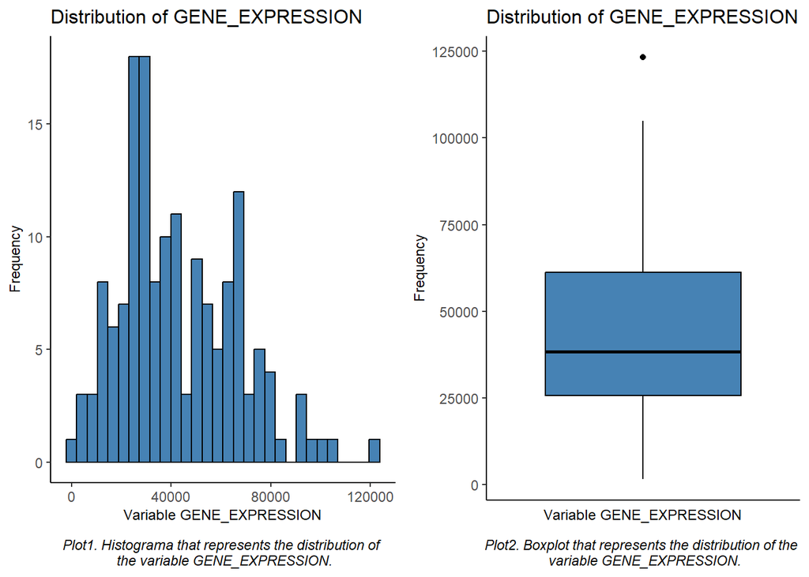

*Distribution of GENE_EXPRESSION in women and men*

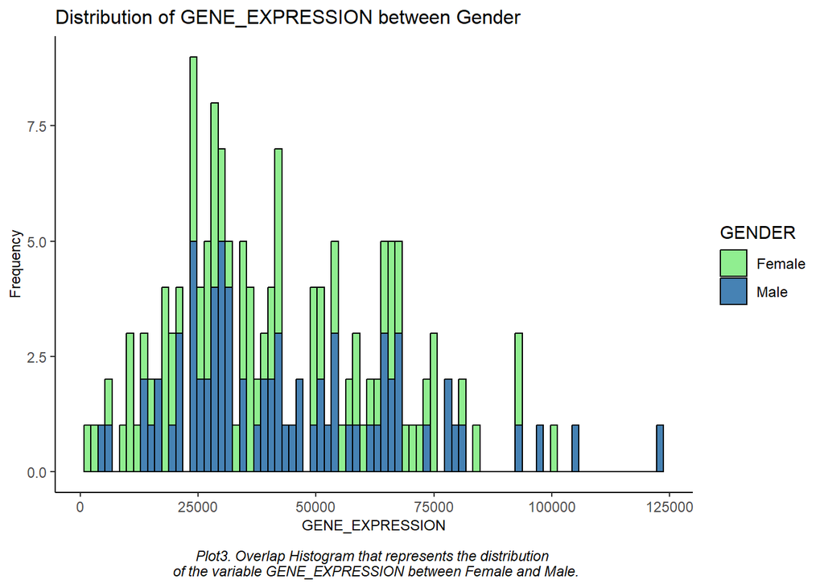

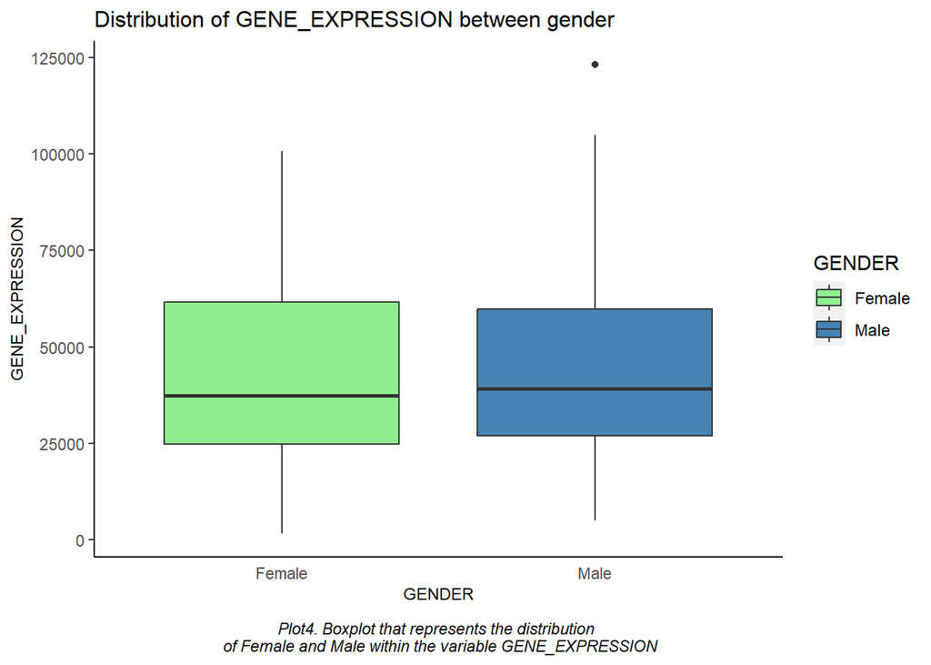

*Proportion of women and men within SNP1*

For this case, we represent the proportion of women and men for each genotype of SNP1. First we show the table with the representation of the values, and then the bar plot with labels representing the proportion in percentage.

To represent the table, we use **knitr::kable** and **kableExtra**

Table2. Proportion of women and men within SNP1.

| SNP1 | GENDER | Freq | Prop |
| --- | --- | --- | --- |
| CC | Female | 4 | 0.333 |
| CC | Male | 8 | 0.667 |
| CT | Female | 26 | 0.491 |
| CT | Male | 27 | 0.509 |
| TT | Female | 52 | 0.565 |
| TT | Male | 40 | 0.435 |

Be careful because if we use **knitr::kable and kableExtra**, returns a **table type object** . **ggplot2** only accepts **data.frame type object** . This is why if we try to represent the table and the graph in a single set, Rstudio does not allow it, so we have to divide it into two sets.

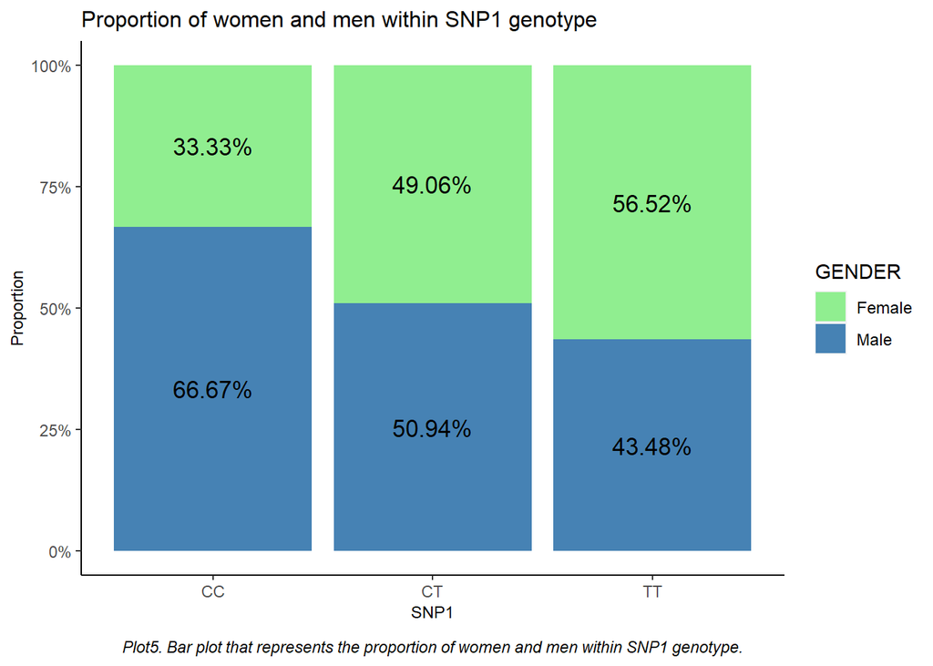

*Proportion of each genotype SNP5 within Cases and Controls*

First we need to convert 0 and 1 (number) as Control and Case (factor) with the function **factor()**. 0 will be Control whereas 1 will be Case. Here we can see the results represented in a table and in a bar plot.

Table3. Proportion of each genotype SNP5 within Cases and Controls.

[output not shown]

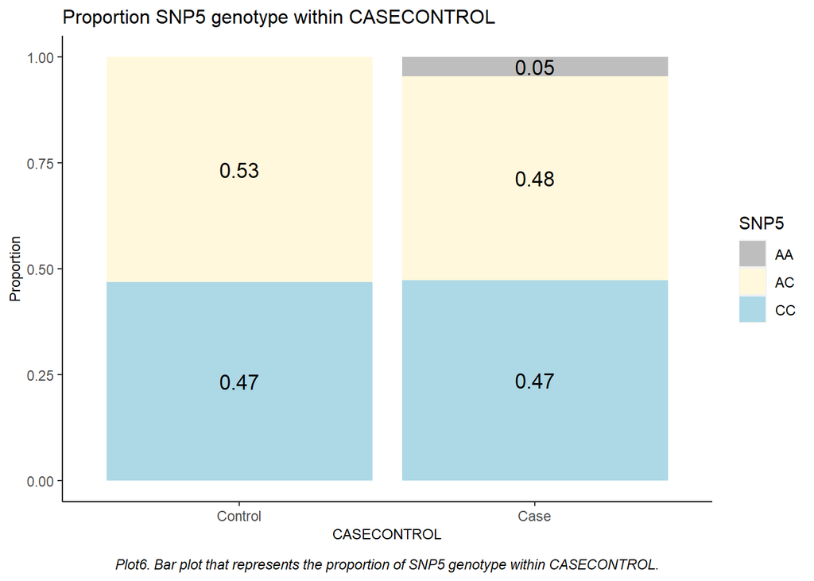

*Proportion of women and men older than 35 within CASECONTROL*

We use **filter()** because in this case, we only want the individuals older than 35 years old.

[output not shown]

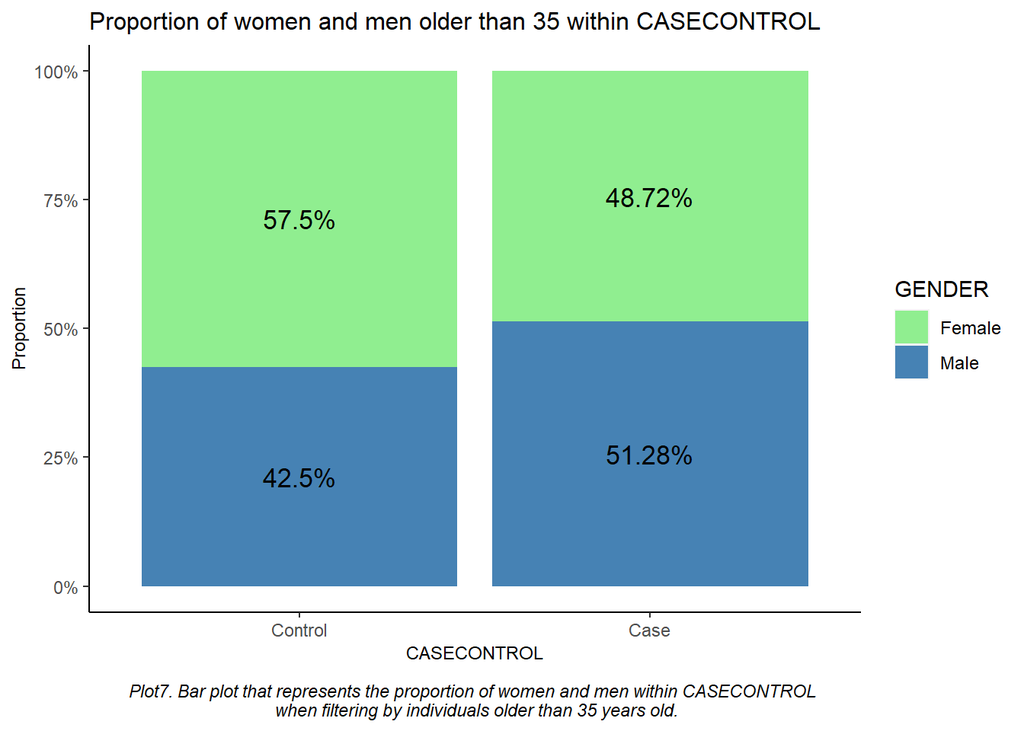

*Frequency of each SNP1 genotype within GENDER*

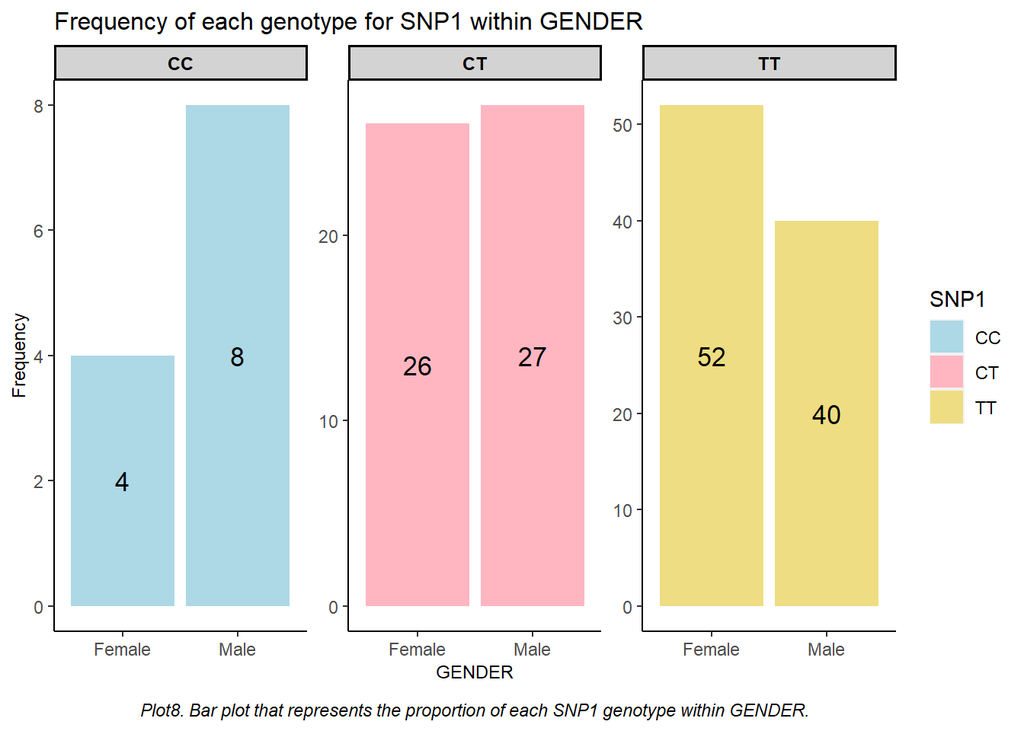

*Frequency for each genotype across all the SNPS that we have comparing between women and men*

For this part, we use **facet_grid()** function in ggplot2, which is used to create multiple plots based on two categorical variables. In this case, our categorical variables are GENDER and SNP (from snps_long dataset).

Now we need to define a new variable SNP containing all the different SNPS categories (e.g. SNP1,…, SNP5) and a new variable Genotype containing the value for each individual for the specific SNP. To do this step, se use the following code to transform the dataset called data to snps_long dataset:

snps_long<- data %>% pivot_longer(

cols=2:6,

names_to=“SNP”,

values_to=“Genotype”)

Here we show a brief part of how it looks the new dataset snps_long:

| CASECONTROL | GENE_EXPRESSION | AGE | GENDER | SNP | Genotype |
| --- | --- | --- | --- | --- | --- |
| Case | 75640.52 | 43 | Female | SNP1 | TT |
| Case | 75640.52 | 43 | Female | SNP2 | GG |
| Case | 75640.52 | 43 | Female | SNP3 | AA |
| Case | 75640.52 | 43 | Female | SNP4 | AA |
| Case | 75640.52 | 43 | Female | SNP5 | CC |
| Case | 28688.22 | 45 | Female | SNP1 | TT |

*Table5. Table of the Dataset snps_long.*

**pivot_longer** function belongs to tidyr R package, and it is used to transform a dataset from wide format to long format. This process is useful when the data is organized in a way that each observation occupies multiple columns and you want to reorganize the structure of the dataframe to facilitate analysis and visualization.

To perform the plot, boxes are divided by SNPs (vertical) and by GENDER (horizontal). We color the bars according to the Genotype variable.

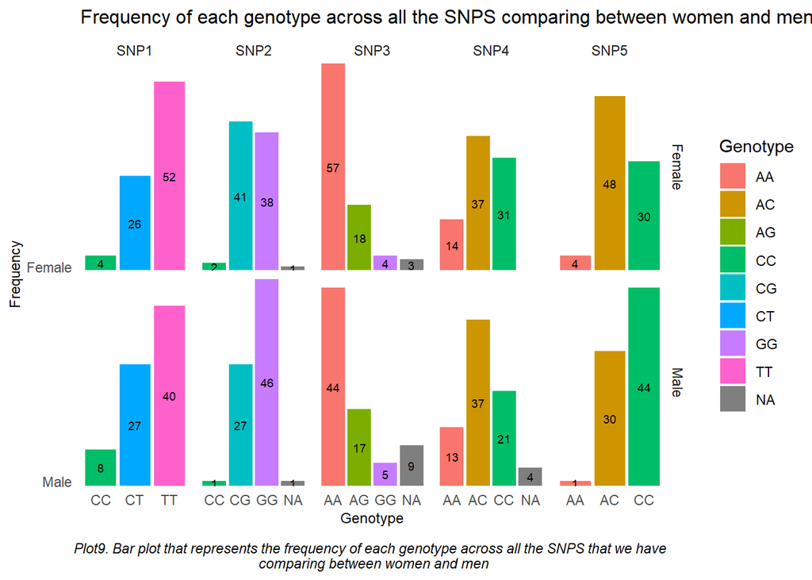

### Conclusions

Finally, we can conclude with some take home messages:

- Implementing advanced graphics in RStudio provides a valuable tool for exploring and communicating complex patterns in data.
- Using packages like ggplot2 and tidyverse simplifies the process of creating advanced graphics. Clear and consistent syntax makes it easier to build complex visualizations with more readable and maintainable code.
- ggplot2 allows a wide range of customizations.
- The ability to incorporate interactive elements into charts, whether through ggplotly or other tools, improves the user experience by allowing direct exploration of data in the visualization. This is particularly useful for identifying patterns in large, complex data sets.
- In summary, incorporating advanced graphics into RStudio, especially through ggplot2 and tidyverse tools, offers substantial benefits for data analysis, improving the effective exploration, interpretation, and communication of findings.